# homework

###1 ## Question Use knitr to produce at least 3 examples (texts, figures, tables).

## Answer

texts

```r
x=3
sqrt(x)
```

```
## [1] 1.732051
```

figures

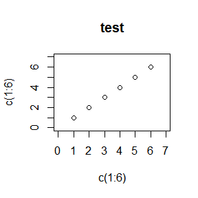

```r
plot(c(1:6),c(1:6),main="test",xlim = c(0,7),ylim = c(0,7))
```

tables

```r
cityofstudent= c("武汉","合肥","南京","合肥","上海")
table(cityofstudent)
```

```
## cityofstudent
## 合肥 南京 上海 武汉
##    2    1    1    1
```

###2 Question:

Use R & knitr to solve Exercises 3.4, 3.11, and 3.20 (pages 94-96, Statistical Computating with R)

习题3.04

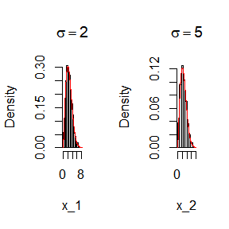

```r
set.seed(123)
n<-1000
u<-runif(n)
y<-seq(0,20,.01)

par(mfrow=c(1,2))
#sigma=2的情形，可以看出拟合较好
sig_1<-2


x_1<-sqrt(-2*sig_1^2*log(1-u))
hist(x_1,probability = T,main=expression(sigma==2))
#添加理论密度曲线,图中为红线
lines(y,y/sig_1^2*exp(-y^2/(2*sig_1^2)),col="red")

#sigma=5的情形，可以看出拟合较好
sig_2<-5

x_2<-sqrt(-2*sig_2^2*log(1-u))
hist(x_2,probability = T,main=expression(sigma==5))
#添加理论密度曲线,图中为红线

lines(y,y/sig_2^2*exp(-y^2/(2*sig_2^2)),col="red")
```

3.11

```r
bif<-function(p)
{
#定义函数bif,输入p_1=p,输出对应混合分布直方图
n<-1e3
X1<-rnorm(n,0,1)
X2<-rnorm(n,3,1)
p_1<-p;p_2<-1-p_1
r<-sample(c(0,1),n,replace = T,prob = c(p_2,p_1))
Z<-r*X1+(1-r)*X2
hist(Z,main="")
}
```

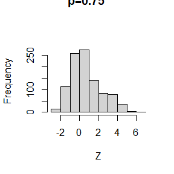

```r
set.seed(123)
#输出p_1=0.75时的混合分布直方图
bif(0.75)
title(main="p=0.75",outer = T)
```

```r
#输出p_1=0.1,...,1时的混合分布直方图
par(mfrow=c(2,5))
```

[output not shown]

习题3.20  
首先对hint进行证明: 由于$Y_i$与$N(t)$独立,且$Y_i$相互独立

因此$E[X(t)]=E[\sum_{i=1}^{N(t)}Y_i]=E[N(t)]E[Y_1]=λtE[Y_1]$

同时$Var(X(t))=E[X^2(t)]−(E[X(t)])2$

$=E[\sum^{N(t)}_{i=1}Y^2_i+2 \sum_{i=1}^{N(t)}\sum_{j=1}^{i-1}Y_iY_j]−λ^2t^2E^2[Y_1]$

$=E[\sum^{N(t)}_{i=1}Y^2_i+2 \frac{N(t)(N(t)-1)}{2}Y_iY_j −λ^2t^2E^2[Y_1]$

$=λtE[Y^2_1]−λtE^2[Y_1]$

因此，当$t=10$时

$E[X(10)]=10λE[Y_1]=10λ \frac{α}{λ_y}$

将不同的参数值代入即可求得不同的$E[X(10)]$和 $Var[X(10)]$

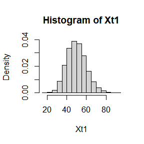

```r
n<-1e4
lambda1<-5
t<-10
Nt1<-rpois(n,lambda1*t)
afa<-1
beta<-1
#此处将Yi的概率密度参数设置为Ga（1，1）
Xt1<-rgamma(n,afa*Nt1,beta)
#由于Yi独立同分布，其和服从Ga（Nt1，1）
hist(Xt1,prob=TRUE)
```

```r
EX1<-sum(Xt1)*{1/n}
VarX1<-sum((Xt1-EX1)^2)*{1/(n-1)}
#此处计算出由随机数生成的样本观测值的均值和方差
TRUEEX1<-t*lambda1*afa/beta
TRUEVarX1<-t*lambda1*(afa^2+afa)/beta
#此处计算出由公式得出的理论均值和方差
EX1/TRUEEX1
```

```
## [1] 0.9991288
```

```r
VarX1/TRUEVarX1
```

```
## [1] 0.9986895
```

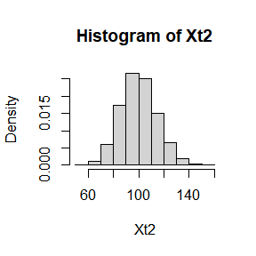

```r
#通过相除得出λ=5时，理论与实际比值在1附近
lambda2<-10
Nt2<-rpois(n,lambda2*t)
Xt2<-rgamma(n,afa*Nt2,beta)
hist(Xt2,prob=TRUE)
```

```r
EX2<-sum(Xt2)*{1/n}
VarX2<-sum((Xt2-EX2)^2)*{1/(n-1)}
TRUEEX2<-t*lambda2*afa/beta
TRUEVarX2<-t*lambda2*(afa^2+afa)/beta
EX2/TRUEEX2
```

```
## [1] 1.002266
```

```r
VarX2/TRUEVarX2
```

```
## [1] 1.023286
```

```r
#此处取λ=10，比值依旧在1附近
```

###3 Question: Exercises 5.4, 5.9, 5.13, and 5.14 (pages 149-151, Statistical Computating with R).

Answers  
习题5.4  
用蒙特卡洛方法模拟贝塔函数的分布，其中$X$取值为0.1，0.2,…,0.9

```r
g<-function(x){mean((1/beta(3,3))*(x^2)*(1-x)^2)}
m <- 10000#重复10000次
estimates=matrix(0,9,2)
for (i in 1:9) {
  x <- runif(m,0,i/10)#将9次试验的值赋值到矩阵里
    estimates[i, 1] <- (i/10)*g(x)
    estimates[i, 2] <- pbeta(i/10,3,3)}
estimates#展示函数的估计值与真实值，第一列为估计值，第二列为真实值
```

```
##              [,1]    [,2]
##  [1,] 0.008562692 0.00856
##  [2,] 0.058052604 0.05792
##  [3,] 0.163574228 0.16308
##  [4,] 0.318851222 0.31744
##  [5,] 0.501187299 0.50000
##  [6,] 0.685150298 0.68256
##  [7,] 0.838056842 0.83692
##  [8,] 0.937215643 0.94208
##  [9,] 0.995877354 0.99144
```

从结果易得，当重复次数为10000时，函数的估计与真实值之间的误差已经很小，若想继续减小误差，可以增加重复次数。

习题5.9

对于给定函数，用对偶变量模拟其分布，并且计算对偶变量的方差缩减百分比。

```r
MC.Phi <- function(x,s, R = 10000, antithetic = TRUE) {
u <- runif(R/2)
if (!antithetic) v <- runif(R/2) else
v <- 1 - u
u <- c(u, v)
cdf <- numeric(length(x))
for (i in 1:length(x)) {se
g <- 1-exp(-(u * x[i])^2 / (2*s^2))
cdf[i] <- mean(g)
}
cdf}#定义对偶函数
m <- 1000
MC1 <- MC2 <- numeric(m)
x <- 2
se=matrix(0,10,1)#对方差进行不同取值，从1，2到10依次选取
for (j in 1:10) {
for (i in 1:m) {
MC1[i] <- MC.Phi(x,j, R = 1000, anti = FALSE)
MC2[i] <- MC.Phi(x,j, R = 1000)
}
se[j,1]=((var(MC1) - var(MC2))/var(MC1))
}
se
```

```
##            [,1]
##  [1,] 0.9973872
##  [2,] 0.9261489
##  [3,] 0.8992949
##  [4,] 0.8828221
##  [5,] 0.8872568
##  [6,] 0.8813183
##  [7,] 0.8826639
##  [8,] 0.8669814
##  [9,] 0.8849073
## [10,] 0.8923244
```

习题5.13

取两个重要性函数，对给定函数$g(x)=\frac{x^2}{\sqrt(2 pi)}exp^(-\frac{x^2}{2})$进行模拟，并判断哪个函数的方差更小。

```r
m <- 100000
theta.hat <- se <- numeric(2)
g <- function(x) {(x^2)/(sqrt(2*pi))*exp(-x^2/2) * (x > 1)}
x <- rexp(m, 1)+1 #第一个函数取近似的指数函数，取值范围为x>1
fg <- g(x) / exp(-x+1)
theta.hat[1] <- mean(fg)
se[1] <- sd(fg)
x <- rnorm(m) #第二个函数取标准正态函数
fg <- g(x) / dnorm(x)
theta.hat[2] <- mean(fg)
se[2] <- sd(fg)
rbind(theta.hat, se)
```

```
##                [,1]      [,2]
## theta.hat 0.4010063 0.3974791
## se        0.1569095 1.1223283
```

两个函数的模拟效果都不错，但是显然第一个函数的方差要小得多，这也是因为第一个函数的取值等因素都与原函数更相似。

习题5.14

通过重要性抽样对上一题中的函数进行蒙特卡洛模拟。

```r
m <- 100000
g <- function(x) {(x^2)/(sqrt(2*pi))*exp(-x^2/2) * (x > 1)}
x <- rexp(m, 1)+1 #函数取近似的指数函数，取值范围为x>1
fg <- g(x) / exp(-x+1)
mean(fg)
```

```
## [1] 0.401487
```

通过模拟可得该函数的估计值。

###4 question  
6.5; 6.A,and homework in pdf

answer

6.5  
Suppose a 95% symmetric t-interval is applied to estimate a mean, but the sample data are non-normal. Then the probability that the confidence interval covers the mean is not necessarily equal to 0.95. Use a Monte Carlo experiment to estimate the coverage probability of the t-interval for random samples of χ2(2) data with sample size n = 20. Compare your t-interval results with the simulation results in Example 6.4. (The t-interval should be more robust to departures from normality than the interval for variance.)  
对n=20的样本进行1000次试验，并求置信区间的覆盖率

```r
n <- 20
alpha <- .05
mu0 <- 2
m <- 1000
uci<-lci <- numeric(m)
c=0
for (i in 1:m) {
x <- rchisq(n,df=2)
uci[i] <- mean(x)+qt(1-alpha/2,n-1)*sd(x)/sqrt(n-1)
lci[i] <- mean(x)-qt(1-alpha/2,n-1)*sd(x)/sqrt(n-1)
c=c+sum(lci[i]<2&uci[i]>2)
}
print(c/10000)
```

[output not shown]

习题6.4的代码

```r
n <- 20
alpha <- .05
UCL <- replicate(1000, expr = {
x <- rnorm(n, mean = 0, sd = 2)
(n-1) * var(x) / qchisq(alpha, df = n-1)
} )
M<-mean(UCL > 4)
M
```

```
## [1] 0.936
```

通过对比可知，6.4的置信区间覆盖率比卡方分布构成的区间更高。

6.A  
Use Monte Carlo simulation to investigate whether the empirical Type I error rate of the t-test is approximately equal to the nominal significance level α, when the sampled population is non-normal. The t-test is robust to mild departures from normality. Discuss the simulation results for the cases where the sampled population is (i) χ2(1), (ii) Uniform(0,2), (iii) Exponential(rate=1). In each case, test H0 : µ = µ0 vs H0 : µ = µ0, where µ0 is the mean of χ2(1), Uniform(0,2), and Exponential(1), respectively.  
既然是用t分布，那不妨取每次的样本大小为20

```r
n <- 20
alpha <- .05
mu0 <- 1
m <- 10000 #number of replicates
p <- numeric(m) #storage for p-values
for (j in 1:m) {
x <- rchisq(n,df=1)
ttest <- t.test(x, alternative = "two.sided", mu = mu0)
p[j] <- ttest$p.value
}
p.hat <- mean(p < alpha)
se.hat <- sqrt(p.hat * (1 - p.hat) / m)
print(c(p.hat, se.hat))
```

```
## [1] 0.10660000 0.00308604
```

取值范围从0到2的均匀分布

```r
n <- 20
alpha <- .05
mu0 <- 1
m <- 10000 #number of replicates
p <- numeric(m) #storage for p-values
for (j in 1:m) {
x <- runif(n,0,2)
ttest <- t.test(x, alternative = "two.sided", mu = mu0)
p[j] <- ttest$p.value
}
p.hat <- mean(p < alpha)
se.hat <- sqrt(p.hat * (1 - p.hat) / m)
print(c(p.hat, se.hat))
```

```
## [1] 0.049600000 0.002171171
```

下面是参数为1的指数分布

```r
n <- 20
alpha <- .05
mu0 <- 1
m <- 10000 #number of replicates
p <- numeric(m) #storage for p-values
for (j in 1:m) {
x <- rexp(n,1)
ttest <- t.test(x, alternative = "two.sided", mu = mu0)
p[j] <- ttest$p.value
}
p.hat <- mean(p < alpha)
se.hat <- sqrt(p.hat * (1 - p.hat) / m)
print(c(p.hat, se.hat))
```

```
## [1] 0.078500000 0.002689568
```

不难发现，三个函数中卡方分布的t1e最大，均匀分布的t1e最小。而且，相应的三次试验的标准差大小也是按照这个顺序排列的。 这并不是巧合，而是因为三个函数中均匀分布的方差最小，为1/3；指数分布次之，是1；卡方分布方差最大，为4。  
从上面结果可以得到结论，分布的方差越小，且对称性越强，用该分布得到的置信区间覆盖率越高。

If we obtain the powers for two methods under a particular simulation setting with 10,000 experiments: say, 0.651 for one method and 0.676 for another method. We want to know if the powers are different at 0.05 level. I What is the corresponding hypothesis test problem? I What test should we use? Z-test, two-sample t-test, paired-t test or McNemar test? Why? I Please provide the least necessary information for hypothesis testing.

设方法1的期望为$\mu_1$，方法2的期望为$\mu_2$.  
那么相应的假设就是$H_0:\mu_1=\mu_2 vs H_1:\mu_1\not=\mu_2$  
应当用配对样本t检验，对于该假设问题的10000次试验，我们采取了两种不同的处理方法，我们要检验的是这两种方法之间是否存在显著差异。 所以应当用配对样本t检验。  
所需的数据有：置信度$\alpha$,两种方法对于一万次试验中的各个样本的p值。

###5 6.c Repeat Examples 6.8 and 6.10 for Mardia’s multivariate skewness test. Mardia [187] proposed tests of multivariate normality based on multivariate generalizations of skewness and kurtosis. If X and Y are iid, the multivariate population skewness $\beta_{1,d}$ is defined by Mardia as
$$\beta_{1,d}=E[(X-\mu)^T\Sigma^{-1}(Y-\mu)]^3.$$
Under normality, $\beta_{1,d}=0.$ The multivariate skewness statistic is
$$b_{1,d}=\frac{1}{n^2}\Sigma_{i,j=1}^{n}((X_i-\bar X)^T\hat{\Sigma}^{-1}(X_j-\bar X))^3,$$
where $\hat\Sigma$ is the maximum likelihood estimator of covariance. Large values of $b_{1,d}$ are significant. The asymptotic distribution of $nb_{1,d}/6$ is chisquared with $d(d + 1)(d + 2)/6$ degrees of freedom.

例6.8多元情形下

```r
library(MASS)
n <- c(10, 20,50,100) #样本大小
d <- 4#多元正态的维数
cv1 <- qchisq(.95, d*(d+1)*(d+2)/6) #确定维数下的拒绝域上界临界值（还需乘以6/n）

sk <- function(x) {
#计算样本偏度系数
mu<-numeric(d)
sigma<-diag(d)
x <- mvrnorm(n[i],mu,sigma)
xbar<-colMeans(x)
SIGMA<- matrix(data=0, nrow = d, ncol =d)
for (a in 1:n[i]){
  SIGMA=SIGMA+(1/n[i])*(x[a,]-xbar)%o%(x[a,]-xbar)
}
SIGMA1=solve(SIGMA)
beta1=0
for (a in 1:n[i]){
  for (b in 1:n[i]){
    beta1=((1/n[i])^2)*((x[a,]-xbar)%*%SIGMA1%*%(x[b,]-xbar))^3+beta1
}
}
return( beta1)
}
p.reject <- numeric(length(n)) #保存样本偏度系数的模拟结果
m <- 200 #每次实验重复200次
for (i in 1:length(n)) {
sktests <- numeric(m)
for (j in 1:m) {
#拒绝原假设为1
sktests[j] <- as.integer(abs(sk(x)) >= 6*cv1/n[i])
}
p.reject[i] <- mean(sktests) #拒绝的概率
}
p.reject
```

```
## [1] 0.000 0.010 0.020 0.035
```

从结果可以看出，随着样本量增大，检验的t1e也变得更加稳定且合理.

例6.10在多元情况下的结果

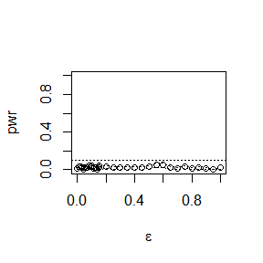

```r
alpha <- .1
d=5
n <- 30
m <- 100
epsilon <- c(seq(0, .15, .01), seq(.15, 1, .05))
N <- length(epsilon)
pwr <- numeric(N)
sk <- function(x) {
#计算样本偏度系数
mu<-numeric(d)
sigma <- diag(c(sample(c(1, 10), replace = TRUE,
size =d, prob = c(1-e, e))))
x <- mvrnorm(n,mu,sigma)
xbar<-colMeans(x)
SIGMA<- matrix(data=0, nrow = d, ncol =d)
for (a in 1:n){
  SIGMA=SIGMA+(1/n)*(x[a,]-xbar)%o%(x[a,]-xbar)
}
SIGMA1=solve(SIGMA)
beta1=0
for (a in 1:n){
  for (b in 1:n){
    beta1=((1/n)^2)*((x[a,]-xbar)%*%SIGMA1%*%(x[b,]-xbar))^3+beta1
}
}
return( beta1)
}
cv <- qchisq(.95, d*(d+1)*(d+2)/6) #确定维数下的拒绝域上界临界值（还需乘以6/n）
for (j in 1:N) {
e <- epsilon[j]
sktests <- numeric(m)
for (i in 1:m) {
sktests[i] <- as.integer(abs(sk(x)) >= 6*cv/n)
}
pwr[j] <- mean(sktests)
}
#画出图形
plot(epsilon, pwr, type = "b",
xlab = bquote(epsilon), ylim = c(0,1))
abline(h = .1, lty = 3)
se <- sqrt(pwr * (1-pwr) / m)
lines(epsilon, pwr+se, lty = 3)
lines(epsilon, pwr-se, lty = 3)
```

随着$\epsilon$的变化，power的变化并不明显。

###6 Answer: Exercises 7.7, 7.8, 7.9, and 7.B (pages 213, Statistical Computating with R).

7.7

```r
library(bootstrap)
library(MASS)
x<-scor
la<-function(x){
  xbar<-colMeans(x)
  n=88
SIGMA<- matrix(data=0, nrow = 5, ncol =5)
for (a in 1:n){
  t<-as.numeric(x[a,]-xbar)
  SIGMA=SIGMA+(1/n)*(t)%o%(t)
}
ev<-eigen(SIGMA)
lambda<-sum(ev$val)
lambda1<-ev$val[1]
theta<-lambda1/lambda
return(theta)
}
lambda.hat<-la(x)

B <- 1e2;
thetastar <- numeric(B)
for(b in 1:B){
mb <- 1:88
nmb <- sample(mb,replace=TRUE)
xstar=matrix(data=0, nrow = 88, ncol =5)
for (j in 1:88) {
xstar[j,]<-as.numeric(x[nmb[j],])
}
thetastar[b] <-la(xstar)
}

round(c(bias=mean(thetastar)-lambda.hat,
se=sd(thetastar)),2)
```

```
## bias   se
## 0.00 0.05
```

可以得到bootstrap方法估计得$\hat\lambda$得bias和标准差。

7.8

```r
library(bootstrap)
library(MASS)
x<-scor
la<-function(x){
  xbar<-colMeans(x)
  n=dim(x)[1]
SIGMA<- matrix(data=0, nrow = 5, ncol =5)
for (a in 1:n){
  t<-as.numeric(x[a,]-xbar)
  SIGMA=SIGMA+(1/n)*(t)%o%(t)
}
ev<-eigen(SIGMA)
lambda<-sum(ev$val)
lambda1<-ev$val[1]
theta<-lambda1/lambda
return(theta)
}
lambda.hat<-la(x)
thetastar<-numeric(88)
for(b in 1:88){
xt<-x[-b,]
thetastar[b] <-la(xt)
}

round(c(bias=87*(mean(thetastar)-lambda.hat),
se=sd(thetastar)),2)
```

```
## bias   se
## 0.00 0.01
```

7.9

```r
library(bootstrap)
library(MASS)
x<-scor
la<-function(x){
  xbar<-colMeans(x)
  n=88
SIGMA<- matrix(data=0, nrow = 5, ncol =5)
for (a in 1:n){
  t<-as.numeric(x[a,]-xbar)
  SIGMA=SIGMA+(1/n)*(t)%o%(t)
}
ev<-eigen(SIGMA)
lambda<-sum(ev$val)
lambda1<-ev$val[1]
theta<-lambda1/lambda
return(theta)
}
lambda.hat<-la(x)

B <- 1e2;
thetastar <- numeric(B)
for(b in 1:B){
mb <- 1:88
nmb <- sample(mb,replace=TRUE)
xstar=matrix(data=0, nrow = 88, ncol =5)
for (j in 1:88) {
xstar[j,]<-as.numeric(x[nmb[j],])
}
thetastar[b] <-la(xstar)
}
pc=lambda.hat+qnorm(0.95)*sd(thetastar)
BCa=c(lambda.hat-qnorm(0.975)*sd(thetastar),lambda.hat+qnorm(0.975)*sd(thetastar))
l=BCa[1]
u=BCa[2]
round(c(percentile=pc,lowerBCa =l,upperBCa =u),3)
```

```
## percentile   lowerBCa   upperBCa
##      0.700      0.522      0.716
```

7.b

normal populations (skewness 0)

```r
#standard normal
n=1000
cv1 <- qnorm(.975)
cv2 <- qnorm(.025)
p.reject<-X <- numeric(n) #保存样本偏度系数的模拟结果
for (i in 1:n) {
X[i]=rnorm(1,0)
}
xbar<-mean(X)
xse<-sd(X)
for (j in 1:n) {
#拒绝原假设为1
p.reject[j] <- as.integer(X[j]>=cv1)|as.integer(X[j]<=cv2 )
}
p.reject1=mean(p.reject)
#standard normal sampling confidence interval
sv1 <- xbar+qnorm(.975) *xse
sv2 <-xbar+ qnorm(.025)*xse
for (j in 1:n) {
#拒绝原假设为1
p.reject[j] <- as.integer(X[j]>=sv1)|as.integer(X[j]<=sv2 )
}
p.reject2=mean(p.reject)
#standard normal bootstrap confidence interval
for (i in 1:n) {
X[i]=rnorm(1,0)
}
thetastar <- numeric(1000)
for(b in 1:1000){
xstar <- sample(X,replace=TRUE)
thetastar[b] <- mean(xstar)
}
bv1 <-mean(thetastar)+qnorm(.975)*sd(thetastar)
bv2 <-mean(thetastar)+qnorm(.025)*sd(thetastar)
for (j in 1:1000) {
#拒绝原假设为1
p.reject[j] <- as.integer(thetastar[j]>=bv1)|as.integer(thetastar[j]<=bv2 )
}
p.reject3=mean(p.reject)
round(c(p1=p.reject1,p2=p.reject2,p3=p.reject3),3)
```

```
##    p1    p2    p3
## 0.046 0.054 0.047
```

自由度为5的卡方分布(positive skewness).

```r
#standard normal
n=1000
cv1 <- qchisq(.975,5)
cv2 <- qchisq(.025,5)
p.reject<-X <- numeric(n) #保存样本偏度系数的模拟结果
X=rchisq(df=5,n)
xbar<-mean(X)
xse<-sd(X)
for (j in 1:n) {
#拒绝原假设为1
p.reject[j] <- as.integer(X[j]>=cv1)|as.integer(X[j]<=cv2 )
}
p.reject1=mean(p.reject)
#standard normal sampling confidence interval
sv1 <- xbar+qchisq(.975,5) *xse
sv2 <-xbar+ qchisq(.025,5)*xse
for (j in 1:n) {
#拒绝原假设为1
p.reject[j] <- as.integer(X[j]>=sv1)|as.integer(X[j]<=sv2 )
}
p.reject2=mean(p.reject)
#standard normal bootstrap confidence interval
X=rchisq(df=5,n)
thetastar <- numeric(1000)
for(b in 1:1000){
xstar <- sample(X,replace=TRUE)
thetastar[b] <- mean(xstar)
}
bv1 <-mean(thetastar)+qchisq(.975,5)*sd(thetastar)
bv2 <-mean(thetastar)+qchisq(.025,5)*sd(thetastar)
for (j in 1:1000) {
#拒绝原假设为1
p.reject[j] <- as.integer(thetastar[j]>=bv1)|as.integer(thetastar[j]<=bv2 )
}
p.reject3=mean(p.reject)
round(c(p1=p.reject1,p2=p.reject2,p3=p.reject3),3)
```

```
##    p1    p2    p3
## 0.047 0.813 0.793
```

###7

QUESTION:9.3 AND 9.8

9.3 已知标准柯西分布就是自由度为1的t分布，那么可以套用例题6.6.2

```
set.seed(212)
 rw.Metropolis <- function(n, sigma, x0, N) {
       # n: degree of freedom of t distribution
       # sigma:  standard variance of proposal distribution N(xt,sigma)
       # x0: initial value
       # N: size of random numbers required.
        x <- numeric(N)
        x[1] <- x0
        u <- runif(N)
        k <- 0
        for (i in 2:N) {
            y <- rnorm(1, x[i-1], sigma)
                if (u[i] <= (dt(y, n) / dt(x[i-1], n)))
                    x[i] <- y
                else {
                    x[i] <- x[i-1]
                    k <- k + 1
                }
            }
        return(list(x=x, k=k))
        }

    n <- 1  #degrees of freedom for target Student t dist.
    N <- 2000
    sigma <- c(.05, .5, 2,  16)
    jchs<-matrix(0, N, 2)
    for (v in 1:100){
    jchs[v] <-  jchs[v]+10
    jchs[v+1] <-  jchs[v]+10
    jchs[2*v] <-  jchs[v]+20
    if (jchs[2*v]>jchs[v])
        jchs[v]<-1
    else jchs[v]<-0
    }

    x0 <- 10 #初始值
    rw1 <- rw.Metropolis(n, sigma[1], x0, N)
    rw2 <- rw.Metropolis(n, sigma[2], x0, N)
    rw3 <- rw.Metropolis(n, sigma[3], x0, N)
    rw4 <- rw.Metropolis(n, sigma[4], x0, N)

    #number of candidate points rejected
    print(c(rw1$k, rw2$k, rw3$k, rw4$k)/N)

    par(mfrow=c(2,2))  #display 4 graphs together
    refline <- qt(c(.025, .975), df=n)
    rw <- cbind(rw1$x, rw2$x, rw3$x,  rw4$x)
    for (j in 1:4) {
        plot(rw[,j], type="l",
             xlab=bquote(sigma == .(round(sigma[j],3))),
             ylab="X", ylim=range(rw[,j]))
        abline(h=refline)
    }
    par(mfrow=c(1,1)) #reset to default

    a<- c(.05,seq(.1,.9,.1),.95)
    Q<- qt(a,n)
    rw<- cbind(rw1$x, rw2$x, rw3$x, rw4$x)
    mc<-rw[501:N, ]
    Qrw<- apply(mc,2,function(x) quantile(x,a))
    print(round(cbind(Q, Qrw), 3)) #not show
        mc<-t(mc)

    Gelman.Rubin <- function(psi) {
        # psi[i,j] is the statistic psi(X[i,1:j])
        # for chain in i-th row of X
        psi <- as.matrix(psi)
        n <- ncol(psi)
        k <- nrow(psi)

        psi.means <- rowMeans(psi)     #row means
        B <- n * var(psi.means)        #between variance est.
        psi.w <- apply(psi, 1, "var")  #within variances
        W <- mean(psi.w)               #within est.
        v.hat <- W*(n-1)/n + B/n+(B/(n*k))     #upper variance est.
        r.hat <- v.hat / W             #G-R statistic
        return(r.hat)
    }
    b=200
    rhat <- rep(0, 1500)
    for (j in b:1500){
        rhat[j] <- Gelman.Rubin(mc[,1:j])}
    plot(rhat[(b+1):1500], type="l", xlab="", ylab="R",ylim=c(1,10))
    abline(h=1.2, lty=2)
```

9.8

```r
    set.seed(212)
    N <- 5000               #length of chain
    burn <- 1000            #burn-in length
    X <- matrix(0, N, 2)    #the chain, a bivariate sample
    n1 <- 200                 #parameter n
    a <- 2
    b <- 3

    ###### generate the chain #####

    X[1, ] <- c(0.5, 100)            #initialize

    for (i in 2:N) {
        x2 <- X[i-1, 2]
        X[i, 1] <- rbeta(1,x2+a,n1-x2+b)
        x1 <- X[i, 1]
        X[i, 2] <- rbinom(1,n1,x1)
    }

    b <- burn + 1
    x <- X[b:N, ]

    # compare sample statistics to parameters
    colMeans(x)
```

```
## [1]  0.4004412 79.9857500
```

```r
    cov(x)
```

```
##            [,1]        [,2]
## [1,] 0.03062743    6.095849
## [2,] 6.09584883 1256.809749
```

```r
    cor(x)
```

```
##           [,1]      [,2]
## [1,] 1.0000000 0.9825262
## [2,] 0.9825262 1.0000000
```

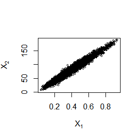

```r
    jchs<-t(x)
    for (v in 1:n1){
    jchs[v] <-  jchs[v]+10
    jchs[v+1] <-  jchs[v]+10
    jchs[2*v] <-  jchs[v]+20
    if (jchs[2*v]>jchs[v])
        jchs[v]<-1
    else jchs[v]<-0
    }

    plot(x, main="", cex=.5, xlab=bquote(X[1]),
         ylab=bquote(X[2]), ylim=range(x[,2]))
```

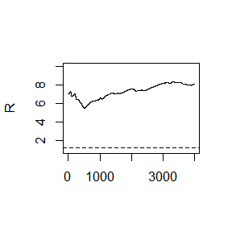

```r
    X<- t(X)
    Gelman.Rubin <- function(psi) {
        # psi[i,j] is the statistic psi(X[i,1:j])
        # for chain in i-th row of X
        psi <- as.matrix(psi)
        n <- ncol(psi)
        k <- nrow(psi)

        psi.means <- rowMeans(psi)     #row means
        B <- n * var(psi.means)        #between variance est.
        psi.w <- apply(psi, 1, "var")  #within variances
        W <- mean(psi.w)               #within est.
        v.hat <- W*(n-1)/n + B/n+(B/(n*k))     #upper variance est.
        r.hat <- v.hat / W             #G-R statistic
        return(r.hat)
        }

    #plot the sequence of R-hat statistics
    rhat <- rep(0, N)
    for (j in b:N){
        rhat[j] <- Gelman.Rubin(X[,1:j])}
    plot(rhat[(b+1):N], type="l", xlab="", ylab="R",ylim=c(1,10))
    abline(h=1.2, lty=2)
```

###8 QUESTION:  
Exercises 11.3 and 11.5

11.3  
使用书中用到的方法，即将数值过大的Gamma函数转化为对数Gamma函数。很容易就得到了我们需要的函数。

```r
#(1)第k项的计算
cpe<-function(d,a,k){
  g=((-1)^k*gamma((d+1)/2))/((2*k+1)*(2*k+2))*exp((2*k+2)*log(sqrt(sum(a^2)))+lgamma(k+3/2)-lgamma(k+1)-k*log(2)-lgamma(k+d/2+1))#第k项的计算公式
g#返回值
  }
```

```r
#(2)给定k后，和的计算
cpe<-function(a,k,e){
  sm=0
  g0=0
  d<-length(a)
  for (i in 0:k) {
    g=((-1)^i*gamma((d+1)/2))/((2*i+1)*(2*i+2))*exp((2*i+2)*log(sqrt(sum(a^2)))+lgamma(i+3/2)-lgamma(i+1)-i*log(2)-lgamma(i+d/2+1))#第k项的计算公式
    sm=g+sm
    if(abs(g0+g)<e)break#如果两次计算的和小于给定值，就跳出循环
    else go=g
  }
  N=1000
  jchs<-matrix(0, N, 2)
    for (v in 1:100){
    jchs[v] <-  jchs[v]+10
    jchs[v+1] <-  jchs[v]+10
    jchs[2*v] <-  jchs[v]+20
    if (jchs[2*v]>jchs[v])
        jchs[v]<-1
    else jchs[v]<-0
    }
  m=c(i,sm)#输出数据为迭代次数以及所求公式的和
  return(m)
}

#(3)给定a为(1,2)时，对于不同k，e的取值进行试验
#k=5，e=1e-10
cpe(a=c(1,2),5,1e-10)
```

```
## [1] 5.000000 1.529729
```

```r
#k=10,e=1e-10
cpe(a=c(1,2),10,1e-10)
```

```
## [1] 10.000000  1.532165
```

```r
#k=20,e=1e-10
cpe(a=c(1,2),20,1e-10)
```

```
## [1] 17.000000  1.532164
```

```r
#k=100,e=1e-100
cpe(a=c(1,2),100,1e-100)
```

```
## [1] 86.000000  1.532164
```

对不同的精度要求，函数停止所需要的次数如上所示

11.5  
本题和11.3类似，对于数值较大的Gamma函数，我们将其转化为对数Gamma函数。以避免我们得到结果为NaN等情形。

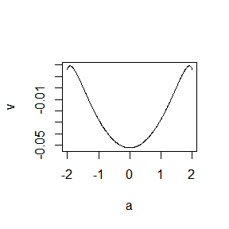

```r
#第十四题公式
slu4 <- function(a, k){
  v1 =sqrt(a^2*(k-1)/(k-a^2))
  v2 =sqrt(a^2*k/(k+1-a^2))
  pt(v1, df = k-1) - pt(v2, df = k)
}
#第一步，先画出两函数差的图像：左减右
f<-function(u,k){
  (1+u^2/k)^(-(k+1)/2)#定义被积函数
}
slu5=function(a,k){#定义两函数的差
  v1 =sqrt(a^2*(k-1)/(k-a^2))
  v2 =sqrt(a^2*k/(k+1-a^2))
  gg=(log(k) - log(k-1))/2 + (2*lgamma(k/2) - lgamma((k+1)/2)- lgamma((k-1)/2)) + log(integrate(f,lower = 0,upper =v1 ,rel.tol =1e-5,k=k-1)$value)-log(integrate(f,lower = 0,upper =v2 ,rel.tol =1e-5,k=k)$value)
  return(gg)
}
k=4
#k=4时的图像
a=seq(-2,2,0.01)#在如下区间里进行作图
v=rep(0,length(a))
for (i in 1:length(a)) {
  v[i]=slu5(a[i],k)
}
plot(a,v,type = "l")
```

```r
#可以看到在接近1.5的地方，函数有根。

#（2）下面求根
it <- 0
eps <- 1e-50#误差阈值
vec=c(4:25,100,500,1000)
sluo5 <- sapply(vec, function(k){uniroot(slu5, interval = c(1, 2), k=k)$root})
sluo4 <- sapply(vec, function(k){uniroot(slu4, interval = c(1, 2), k=k)$root})
root <- cbind(sluo5, sluo4)
colnames(root) <- c("11.5的根", "11.4的根")
rownames(root) <- as.character(vec)

knitr::kable(root)
```

|  | 11.5的根 | 11.4的根 |
| --- | --- | --- |
| 4 | 1.492088 | 1.492103 |
| 5 | 1.533559 | 1.533556 |
| 6 | 1.562747 | 1.562744 |
| 7 | 1.584435 | 1.584430 |
| 8 | 1.601193 | 1.601185 |
| 9 | 1.614533 | 1.614521 |
| 10 | 1.625405 | 1.625390 |
| 11 | 1.634436 | 1.634419 |
| 12 | 1.641997 | 1.642038 |
| 13 | 1.648515 | 1.648554 |
| 14 | 1.654154 | 1.654190 |
| 15 | 1.659080 | 1.659114 |
| 16 | 1.663420 | 1.663452 |
| 17 | 1.667273 | 1.667304 |
| 18 | 1.670716 | 1.670745 |
| 19 | 1.673812 | 1.673840 |
| 20 | 1.676611 | 1.676637 |
| 21 | 1.679153 | 1.679178 |
| 22 | 1.681471 | 1.681496 |
| 23 | 1.683594 | 1.683620 |
| 24 | 1.685546 | 1.685572 |
| 25 | 1.687347 | 1.687373 |
| 100 | 1.720599 | 1.720608 |
| 500 | 1.729745 | 1.729756 |
| 1000 | 1.730897 | 1.730908 |

EM算法
仅用观测数据得到极大似然估计的似然函数为
$$L(y|\lambda)=0.7^{10}\lambda e^{-\lambda \sum_{i=1}^{7}y_i}$$
容易求得$\lambda$的极大似然估计为
$$\hat \lambda=\frac{1}{ \sum_{i=1}^{7}y_i}=0.267$$

而用EM算法如下 已知似然函数为$f(y|\lambda)\propto \Pi^{10}_{i=1}P(y_i)$;
令$y=y^1+y^2$,则有$\pi(\lambda|y)\propto \lambda \Pi^{y^1}_{i=1}P(y_i^1)P(y^2_i)^3=\lambda e^{-\lambda \sum_{i=1}^{7}y_i^1}e^{-\lambda \sum_{i=1}^{3}y_i^2}$;
因此E-M算法中的E步为
$$Q(\lambda,\hat \lambda^{(i)})=E\{[Z_iln\lambda-\lambda\sum y_i^1-\lambda \sum y_i^2]|y,\hat \lambda^{(i)}\}$$

下面进行第M步，最大化Q,对Q求$\lambda$的偏导
得到
$$\hat \lambda^{(i+1)}=\frac{E[Z_i]}{\sum y_i-E[Z_i]}$$
; 其中
$$Z \sim B(10,p),p=\int_{0}^{1}\hat \lambda^ie^{-\hat \lambda^i}$$
,故
$$\hat \lambda^{(i+1)}=\frac{7-7e^{-\hat \lambda^i}}{9.8+E[Z_i]}$$

问题得证

```r
lambda_hat=1
for (i in 1:9) {
  lambda_hat<- (7*exp(lambda_hat)-7)/(exp(lambda_hat)+9.8)
}
lambda_hat
```

```
## [1] 0.2769207
```

###9

## Question

Exercise 1 and 5(page204,Advanced R)

Exercise 1 and 7(page214,Advanced R)

## Answer

page204: 1: Since the essence of the lapply function is to iterate through each element of a list vector and process its elements using the specified function, the lapply function returns the list vector. For lapply(trims,function(trim) mean(x,trim=trim)), it means that for the given vector trims<-c(0,0.1,0.2,0.5), take each element as the parameter trim to be pruned in mean function, For example, when trimS is 0.1, it means that the maximum and minimum 100*0.1=10 digits are deleted and then the average value is taken. For Lapply (trims,mean,x=x), elements in the given vector TRIMs are directly taken as parameters in mean function, and x is taken as other parameters in Lapply. Therefore, there is no need to define function in addition, and the results obtained are the same.

page 204: 5:

```r
rsq <- function(mod) summary(mod)$r.squared
formulas <- list(
  mpg ~ disp,
  mpg ~ I(1 / disp),
  mpg ~ disp + wt,
  mpg ~ I(1 / disp) + wt
)
zt1<-lapply(formulas, lm,data=mtcars)
zt2<-lapply(zt1,rsq)
print(zt2)
```

```
## [[1]]
## [1] 0.7183433
##
## [[2]]
## [1] 0.8596865
##
## [[3]]
## [1] 0.7809306
##
## [[4]]
## [1] 0.8838038
```

page 214: 1(a):

```r
x<-data.frame(cbind(x1=seq(2,8,2),x2=c(1:4)))
zt<-vapply(x, sd, FUN.VALUE = c('a'=0))
print(zt)
```

```
##       x1       x2
## 2.581989 1.290994
```

```r
#结果显示第一列向量（2，4，6，8）的标准差为2.581989，第二列向量（1，2，3，4）的标准差为1.290994
```

(b):

```r
x<-data.frame(a=1:5,b=runif(5),c=c(TRUE,FALSE,TRUE,FALSE,TRUE))
zt1<-vapply(x, is.numeric, logical(1))
zt2<-vapply(x[zt1], sd, FUN.VALUE = c('a'=0))
print(zt2)
```

```
##         a         b
## 1.5811388 0.1201221
```

page 214:7:

```r
function (cl = NULL, X, fun, ..., chunk.size = NULL)
{
    cl <- defaultCluster(cl)
    nchunks <- staticNChunks(length(X), length(cl), chunk.size)
    do.call(c, clusterApply(cl = cl, x = splitList(X, nchunks),
        fun = sapply, FUN = fun, ...), quote = TRUE)
}
```

```
## function (cl = NULL, X, fun, ..., chunk.size = NULL)
## {
##     cl <- defaultCluster(cl)
##     nchunks <- staticNChunks(length(X), length(cl), chunk.size)
##     do.call(c, clusterApply(cl = cl, x = splitList(X, nchunks),
##         fun = sapply, FUN = fun, ...), quote = TRUE)
## }
```

###10

#定义函数

```
#C++ function
library(Rcpp)
cppFunction('NumericMatrix gibbsC(int N, int n,double a,double b,NumericVector x)
{
  NumericMatrix mat(N, 2);
  mat(0,0)=x[1];
  mat(0,1)=x[2];
  for(int i = 1; i < N; i++)
  {
    double y=mat(i-1,1);
    mat(i,0)=rbinom(1,n,y)[0];
    double z=mat(i,0);
    mat(i, 1) = rbeta(1,z+a,n-z+b)[0];
  }
  return mat;
}
')


#R function
gibbsR <- function(N, n,a,b,x)
{
  mat <- matrix(0,N, 2)
  mat[1,]<-x
  a<-0
  b<-0
  N<-0
  for (i in 2:N)
  {
    y<-mat[i-1,2]
    mat[i,2]<-rbinom(1,n,y)
    z<-mat[i,1]
    mat[i,2]<-rbeta(1,z+a,n-z+b)
  }
  return (mat)
}
```

#绘图

[figure not shown]

```r
library(png)
ans1 <- readPNG("~/StatComp21094/data/pic/tuone.png")
r <- nrow(ans1)/ncol(ans1)
plot(c(0,1),c(0,r))
rasterImage(ans1,0,0,1,r)
```

#时间对比

```
library(microbenchmark)
ts <- microbenchmark(C_function=gibbsC(N,  n, a, b,x),R_function=gibbsR(N, n, a, b ,x))
print(summary(ts)[, c(1,3,5,6)])
```